# Voice and Sight

2014 - 2018 Monitoring Results

Colin Leslie

8/19/2020

```r
# Data for behavioral (voice and sight) observations from all three monitoring cycles (2014, 2016, 2018) are combined in a single analysis file. We can read in this file and look at the structure. This file does duplicate visitor group variables from the voice_and_sight_compliance.csv

vs <- read.csv(file = "data/cleanedData/voice_and_sight_compliance.csv", stringsAsFactors = FALSE) %>%
  filter(trainingSession == 0) %>%
  mutate(sessionDate = as.Date(sessionDate, "%m/%d/%Y"),
         timeStart = as.POSIXct(timeStart, format = "%m/%d/%Y %H:%M"),
         timeEnd = as.POSIXct(timeEnd, format = "%m/%d/%Y %H:%M")) %>%
  select(-staff)

# Data for all sessions and visitor groups are also combined into a single analysis file. It contains ALL visitor group variables across all leash and behavioral monitoring components. It contains only one row per visitor group. It was constructed using a left join on the "sessions" dataset, which included sessions where no visitor groups were observed. In these cases, all visitor group vairable, including the visitorID field will be NA and thus can be filtered out if needed by using !is.na(visitorID).

vp_data <- read.csv("data/cleanedData/sessions_visitors.csv", stringsAsFactors = FALSE) %>%
  mutate(sessionDate = as.Date(sessionDate),
         timeStart = as.POSIXct(timeStart),
         timeEnd = as.POSIXct(timeEnd),
         Type = paste(regulation_class, monitoring_type, sep = " - "),
         Leashed = numDog_leashTag + numDog_leashNoTag + numDog_leashUnsure,
         Off_Leash = numDog_offTag + numDog_offNoTag + numDog_offUnsure,
         All_Dogs = Leashed + Off_Leash,
         tag_leash_compliance = case_when(regulation_class == "Voice and Sight" & numDog_offNoTag >= 1 ~ "NonCompliant",
                                          regulation_class == "Voice and Sight" & numDog_offUnsure >= 1 ~ "Unsure",
                                          regulation_class == "Permanent Leash" & Off_Leash >= 1 ~ "NonCompliant",
                                          regulation_class == "Seasonal Leash" & Off_Leash >= 1 ~ "NonCompliant",
                                          TRUE ~ "Compliant")) %>%
  select(-staff)

# data.frame(variable = names(vs),
#            class = sapply(vs, typeof),
#            first_values = sapply(vs, function(x) paste0(head(x),  collapse = ", ")),
#            row.names = NULL) %>%
#   kable() %>%
#   kable_styling() %>%
#   scroll_box(width = "100%", height = "300px")
```

# 1 Introduction

During the summer months of 2014, 2016 and 2018, Open Space and Mountain Parks (OSMP) conducted three monitoring cycles for the Voice and Sight Dog Tag Program (Tag Program). This monitoring program is designed to evaluate compliance rates with dog regulations on OSMP lands and to assist with evaluation of the Tag Program enhancements that were enacted in 2015.

## 1.1 Background

The Voice and Sight Dog Tag Program (Tag Program) is a management strategy within the Education and Outreach, Safety and Enforcement, Recreation Opportunities and User Conflict Reduction Initiatives of the Visitor Master Plan (City of Boulder, 2005). Under the Tag Program, launched in the summer of 2006, visitors wishing to manage their dog(s) off-leash and under voice and sight control are required to have a voice and sight tag visibly displayed on their dogs. From 2006 through 2014, the process of obtaining a voice and sight tag required an applicant to view a video describing the requirements of voice and sight control, acknowledge understanding of those requirements, pay a fee, and complete a registration form. Beginning in 2011, OSMP staff received direction from the Boulder City Council to revise the Voice and Sight Tag Program. Through collaboration between OSMP staff, public stakeholder groups, and individuals, Tag Program enhancements were developed. Program enhancements were implemented in 2015, which now require individuals wishing to participate in the program to attend an hour-long in-person Tag Program training session before they can register with the Tag Program and purchase tag. Dog guardians not registered in the program or who do not have a voice and sight tag visibly displayed on their dog are required to keep their dog on-leash while visiting Open Space and Mountain Parks (OSMP) lands and other City of Boulder properties where voice and sight control is not an option.

Along with the development of the 2015 Tag Program enhancements, the Voice and Sight Dog Tag Monitoring Program (Tag Monitoring Program) was also reviewed, resulting in significant revisions to the existing protocol (used from 2006 and 2010). The new protocol integrated methods developed through and extensive collaboration between OSMP staff, public stakeholder groups, and individuals. The updated monitoring protocol was first enacted as part of the 2014 monitoring cycle and has now fully superseded the previous monitoring protocol that was in effect between 2006 and 2010. The 2016 monitoring cycle also utilized the updated protocol and was the second of three cycles, with monitoring being conducted before (2014), soon after (2016) and scheduled for three years after (2018) implementation of Tag Program enhancements in 2015.

This report has been compiled to provide results from all three monitoring cycles. This report focuses on results from the current monitoring program and provides only a limited discussion of the Voice and Sight Monitoring Program’s genesis. A more comprehensive discussion on development of the 2014 – 2018 monitoring program can be found in the 2014 monitoring report (VanderWoude & Bitume, 2015) and the 2016 monitoring protocol (VanderWoude, Magtanong, & Leslie, 2016).

## 1.2 Goals and Objectives

The goal of the Tag Monitoring Program is to evaluate compliance with OSMP and City of Boulder (CoB) dog regulations by visitors to OSMP lands at a system-wide level. Evaluative measures in the Tag Monitoring Program are based on the goals of the Tag Program. The table below displays Tag Program goals on the left and corresponding monitoring measures on the right.

**Tag Program goals**

- Increase the proportion of dog guardians visiting OSMP lands who have control over their dogs as required by applicable regulations, including proof of current dog rabies vaccinations.
- Maintain a safe, high-quality visitor experience for all
- Contribute to natural resource conservation.

**Monitoring measures**

- Visible voice and sight tag display
- Dog(s) within sight
- Off leash dog(s) under voice control
- No charging, chasing, or otherwise displaying aggression toward any person or dog
- No chasing, harassing or disturbing wildlife or livestock
- No more than 2 dogs off-leash per guardian
- Dog(s) on leash on permanent and seasonally leash required trails

The Tag Program enhancements project’s objective relevant to this monitoring study is to: *Increase compliance with observed dog regulations and voice and sight control rules.*

## 1.3 Guidance from the Visitor Master Plan

The Tag Program is a management strategy within the Education and Outreach, Safety and Enforcement, Recreation Opportunities and User Conflict Reduction Initiatives of the Visitor Master Plan (VMP) (City of Boulder, 2005). Under the Tag Program, launched in the summer of 2006, visitors wishing to manage dogs off-leash and under voice and sight control were required to have a voice and sight tag visibly displayed on their dogs and comply with all other program requirements. The 2005 VMP outlined monitoring measures associated with dog management on OMSP (City of Boulder, 2005 p. 59, 63, 64). All measures initially had a proposed standard of 90% visitor compliance.

Currently potential dog management actions are implemented through Trail Study Area (TSA) processes and plans, with strategies associated with the OSMP management area designation guiding dog management decisions (City of Boulder, 2005 p. 48-50). The VMP established the four management area designations (Passive Recreation Areas, Natural Areas, Agricultural Areas, and Habitat Conservation Areas) based upon characteristics of visitation and current resource status, and describes general management objectives for each. Management strategies for dog management range from voice and sight control with off-trail opportunities (maximum access) to dogs prohibited (no access). Typically, Passive Recreation Areas have the greatest amount of access for dogs/guardians and Habitat Conservation Areas have the least access.

# 2 Methods

The 2014 - 2018 Voice and Sight Monitoring Program consisted of several different monitoring measures associated with dog management on OSMP lands. These include:

- Interactions on Voice and Sight designated trails
- Complinace with carrying a leash on-person for Voice and Sight trails <sup>a</sup>
- Compliance on Leash Required trails
- Compliance on Seasonal Leash Required trails
- On/Off leash ratios on Voice and Sight designated trails <sup>b</sup>

<sup>a</sup> only conducted in 2014

<sup>b</sup> only conducted in 2018

All of the measures were designed to evaluate specific sets of dog management criteria using naturalistic[^1] observation methods that would capture day-to-day, on-the-ground conditions associated with dog management on OSMP lands. The goal of this monitoring effort was to assess conditions at a system-wide scale by conducting randomized field observations that were both spatially and temporally distributed. Constructing a large sample frame of locations, distributed across the majority of the OSMP land system, minimized the probability that conditions at any one location would exhert undue leverage the final results. Again, the goal was to evaluate dog management across the land system as a whole, not to evaluate or “target” any specific locations.

Before we dive into the results, it is worth taking a moment to understand the relationship between the sample selection and analysis process. While the sample selection procedures required staff to select from a randomized combination of locations and times, the actual unit of analysis for all components is the visitor group[^2]. Staff conducted observations at predefined locations were they could view a visitor group as they passed by a specific point or traversed a predefined section of trail. Staff utilized structured coding guides to systematically and objectively record attributes and behaviors of the visitor group under observation.

The specific number of visitor groups that were observed during each three hour period was variable, subject to both the general visitation levels of the location selected as well as random environmental variables, such as weather. It is for this reason that all observations have been aggregated within each observation type. It is neither possible nor appropriate to try and make statistical inferences regarding site specific compliance with dog management regulations.

## 2.1 Regulatory Foundations

The Voice and Sight control definition below serves as the regulatory foundation for which behaviors were included or exempted as part of the methods development.

Boulder Revised Code – Voice and Sight Control Definition (B.R.C. 6-1-2)

“Voice and sight control” means the ability of a guardian or keeper to adequately control a dog by using voice commands and sight commands (such as hand gestures). In order for a guardian or keeper to have voice and sight control over a dog, the guardian or keeper must: (1) be able to see the dog’s actions; and (2) be able to prevent the dog from engaging in the following behaviors, using voice and sight commands, without regard to circumstances or distractions:

1. Charging, chasing or otherwise displaying aggression toward any person or behave toward any person in a manner that a reasonable person would find harassing or disturbing;
2. Charging, chasing or otherwise displaying aggression toward any dog;
3. Chasing, harassing or disturbing wildlife or livestock; or
4. Failing to come to and stay with the guardian or keeper immediately upon command by such person.

## 2.2 Study Area

The study area was bound to designated trails on OSMP that include sanctioned opportunities for guardians to bring dogs on open space. Only properties where OSMP has enforcement responsibility are included. Mountain peaks and other hard to reach areas greater than a 60-minute hike from an access point were excluded from the study area.

Below is an interactive map with locations for each monitoring type (Figure 2.1). Points for permanent and seasonal leash monitoring sites represent the location of line transects across the trail that were used for observing the leash status of dogs in visitor groups as they passed the transect. Voice and sight points represent the location where the observer was stationed such that they could see visitor groups as they traversed previously mapped linear sections of trail. Purple lines represent the field of view that visitor groups were observed across for voice and sight observations. Click on the circle icon to show a pup-up with the location name and number of visitor groups observed each year. Note that sample locations were randomly selected each year so some years might have zero visitor groups either because they were not selected or no visitor groups were observed during the observation session.

[interactive chart not shown]

Figure 2.1: Map of monitoring locations, symbolized by total number of visitor groups observed across all three monitoring years. Purple lines represent the portion of trail that was included in the field of view from the observation point.

### 2.2.1 Site Characteristics

The following criteria were considered when selecting monitoring locations for the current monitoring program. Any given site does not meet or include all criteria; see the 2016 protocol for additional detail on site selection) (VanderWoude et al., 2016):

- Sight distance of at least 400 feet (Voice and Sight component only)
- Audio distance of at least 400 feet (Voice and Sight component only)
- Few visual obstructions on/along trail such as boulders, shrubs, trees, trail undulations or switchbacks
- Ease of access and available legal parking for field technician
- Location along trail continuum; need to represent various locations along the trail (trailhead, first quarter mile, interior)
- Recreation setting (combination of biophysical, managerial and social conditions along with infrastructure development); need to represent a range of recreation settings
- Existence of a potential challenge for dog management (water access, prairie dogs, livestock)
- Topographical setting; need to represent flats, hills, peak access, canyons
- Not within a Trailhead Leash area
- Underlain by OSMP owned and managed property (OSMP has enforcement responsibility)

## 2.3 Sample Selection

Samples for each monitoring component were drawn using multi-stage sampling method to construct a final, randomized list of locations, dates, and start times for observation period (Table 3).

```r
data.frame(stage = c("Stage 1:", "Stage 2:", "Stage 3:"),
           sampleMethod = rep("Simple Random with Replacement", 3),
           additionalCriteria = c("None", "Max = 2 (2016), Max = 3 (2018)", "Only daylight hours (7am – 7pm)")) %>%
  kable(caption = "General sample selection methods for each stage of the multi-stage sample construction",
        col.names = c("Stage", "Sample Method", "Additional Criteria")) %>%
  kable_styling(full_width = FALSE, position = "left")
```

Table 2.1: General sample selection methods for each stage of the multi-stage sample construction

| Stage | Sample Method | Additional Criteria |
| --- | --- | --- |
| Stage 1: | Simple Random with Replacement | None |
| Stage 2: | Simple Random with Replacement | Max = 2 (2016), Max = 3 (2018) |
| Stage 3: | Simple Random with Replacement | Only daylight hours (7am – 7pm) |

By utilizing a simple random sample with replacement for each of the sampling stages, a non-biased sample was constructed such that any given combination of a location, date, and start time had a non-zero probability of being selected for observation. This sample method helped minimize selection bias among high or low use times, dates, or locations within the list of established monitoring sites. As a result, some observation periods occurred during high use times at high use locations while others occurred at low use times and low use locations, as well as all use and location combinations in between those extremes.

## 2.4 Data Collection

### 2.4.1 Voice and Sight Behavioral

The voice and sight component of the monitoring was a naturalistic observational study designed to evaluate dog and guardian compliance with observable aspects of specific dog regulations of the voice and sight ordinances. Data were collected by three dedicated field staff who received extensive training prior to data collection on how to observe visitor group attributes, dog and human behaviors, and guardian responses. Observers utilized a series of data sheets with predefined data fields and value codes to systematically and objectively record attributes and behaviors of the visitor group under observation. Observations were categorized as “pass” events when no dog behaviors were recorded, “interactions” when the dog under observation exhibited a behavior toward another person, dog, wildlife or livestock and as “other” when the dog was out of sight and/or the guardian issued a command (and these observations were not associated with a pass or interaction event). The structure for observation data collected in the field provided context and a chronological understanding of each group’s behaviors and interactions. Once all data collection was completed, field observations were evaluated by the monitoring, Tag Program, and ranger staff to determine a final compliance outcome for each visitor group. This post-collection review reduces the influence of on-site subjectivity and helped normalize compliance determinations across all field staff and observation sessions.

An important part of the B.R.C. code states that guardians must have voice control over their dog while off-leash. To issue a voice and sight command means that the guardian spoke an audible command to the dog with their voice; issued commands may include other signals (including but not limited to vocalizations [words, whistles, whoops, etc.], clapping, or by making noises with their person or a device, or by motions, movements or positions of their person); and that the signal appeared to the observer to be communication intended to establish control of the dog including but not limited to gaining the dog’s attention and/or requiring the dog to stop or return to the guardian.

Specifically, this monitoring program used the following guidance for voice and sight commands:

> *Intended to establish control means that the guardian spoke discreet commands such as “come here” and that the direction of movement of the guardian, tone of voice and/or rate of speech used by the guardian is more urgent or stern than a friendly or relaxed behavior or tone would be.*

For purposes of this report, and to limit ambiguity, we separated commands into those that were clearly meant to establish voice and sight control over a dog and “other attempts” that were less clear. Only commands that included a word or phrase associated with a voice and sight regulation were included in the voice control compliance measure.

For the voice and sight component, overall compliance was calculated by quantifying the following selected measures for each visitor group.

- visible display of voice and sight tag
- dog within sight of guardian
- No more than 2 dogs per guardian
- Wildlife/livestock violation (charging, chasing or disturbing wildlife/livestock)
- Human or dog violation (charging, chasing, or disturbing a human or dog)
- No response to voice and sight command of guardian

If a visitor group was not compliant with any one of these regulations, they were considered noncompliant in the overall compliance measure. However, compliance results for each measure have also been reported separately in the results section. For each measure (individual and overall) the number of noncompliant visitor groups was divided by the total observed groups to obtain the compliance measure.

### 2.4.2 Permanent and Seasonal Leash Required

The permanent and seasonal leash required components evaluated compliance with leash requirements by observing dogs at specific points on designated leash trails across OSMP. The monitoring program included 35 permanent leash required and 8 seasonal leash required monitoring locations.

Field observations were recorded on datasheets using many of the same fields as the voice and sight component to record visitor group attributes and tag display. When a visitor group passed through a designated line transect across the trail the number, leash and tag status of all dogs in the visitor group were recorded. No behaviors were recorded as part of the leash requirement components. Compliance determinations are based solely on whether all dogs in the visitor group were on a leash, regardless of the presence or absence of a voice and sight tag.

## 2.5 Field Methods

For all components, field personnel arrive at the monitoring site at least ten minutes prior to the start of the monitoring period. Most monitoring sites required a hike from the trailhead or other parking area and the time necessary to access the site was appropriately planned for. Once at the locations, staff conducted a continuous three-hour observation session. Field personnel did not wear attire that identified them as OSMP staff and conducted observations from predefined locations set back from the observation zone or transect. This allowed for observers to remain largely inconspicuous so they did not influence the behavior of the visitor group under observation.

### 2.5.1 Voice and Sight Regulations

For voice and sight observations, the observer watched the first visitor group with one or more off-leash dogs that entered the observation area (from any direction). The observer recorded the visitor group data using a structured data sheet with pre-defined fields and observation codes. The observer watched the visitor group the entire time the group remained in the observation area. Once the group being observed left the observation area, the observer waited for a new dog containing group to enter the observation area (so that it could be observed for the entire zone) and repeated the data collection process.

### 2.5.2 Leash Status Observations

For leash status observations, the observer recorded every visitor group with one or more dogs that crossed over the observation point (coming from all directions). The observer recorded the visitor group data using a structured data sheet with pre-defined fields and observation codes.

# 3 Results

## 3.1 General Results and Interpretation

The majority of OSMP trails are included in the master sampling site list. However, as a result of selecting monitoring sites with a maximum of a 60-minute hiking access time, compliance estimates generated by this study should only be generalized to the population of dog guardians that visit trails on OSMP that allow dogs and have similar dog management as to those shown on the map (Figure 2.1).

The monitoring program is designed to gain an understanding of the level of compliance with Voice and Sight requirements, leash regulations and excrement removal across all trails on the OSMP system that met our selection criteria. For each component, we have aggregated data at the yearly level as observations at individual sites were too few to provide statistically confident comparisons between sites.

Depending on the particular measure, not all visitor groups observed necessarily had an opportunity to be evaluated for compliance. For example, entering a closure could only be evaluated if the visitor group was traveling adjacent to an area closure. As such, it is important to consider the associated confidence interval for compliance percentages. Confidence intervals have been calculated using a binomial proportion confidence interval since compliance for each measure can be considered a series of success–failure experiments [Bernoulli trials](https://en.wikipedia.org/wiki/Bernoulli_trial).

## 3.2 Sample Composition

Trained staff conducted direct observation in the field using a randomized sample of locations, dates and times. All collection types and sessions were conducted in three hour blocks. While individual start hours were randomized, we can classify each session broadly into AM, Mid-day, and PM sessions to get a sense of when collections took place across the day. This is significant as we know from both previous research and anecdotal observations that aspects of both human and dog visitation vary throughout the day. Simple randomization of observations times helped to minimize bias of overall results toward any particular type of temporally based visitation pattern.

### 3.2.1 Monitoring Sessions

Monitoring sessions were randomly selected using the criteria described above in the Sample Selection section. There are a number of ways we can cross-tabulate observation sessions, which can be viewed using the tabs below.

#### Aggregated by Year

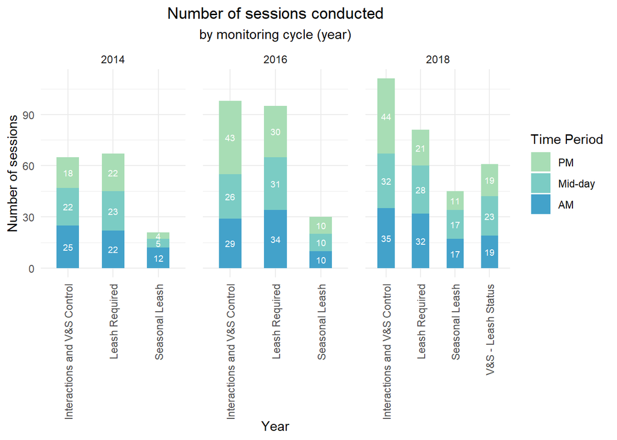

Figure 3.1: Number of monitoring sessions conducted by monitoring type, year and time period of the day.

```r
vp_data %>%
  group_by(year,sessionType, timePeriod) %>%
  summarise(Sessions = n_distinct(sessionID, na.rm = TRUE),
            Visitors = n_distinct(visitorID, na.rm = TRUE)) %>%
  ggplot(., aes(x = factor(sessionType), y = Sessions, fill = fct_rev(timePeriod))) +
  geom_bar(stat = "identity", width = .5) +
  geom_text(aes(label = Sessions), position = position_stack(vjust = .5), color = "white", size = 2.5) +
  #scale_fill_brewer(type = "seq", palette = "PuBuGn") +
  scale_fill_manual(values = c("#a8ddb5", "#7bccc4", "#43a2ca")) +
  theme_minimal() +
  facet_wrap( ~ factor(year), scales = "free_x") +
  xlab("Year") +
  ylab("Number of sessions") +
  labs(title = "Number of sessions conducted",
       subtitle = "by monitoring cycle (year)",
       fill = "Time Period") +
  theme(plot.title = element_text(hjust = 0.5),
        plot.subtitle = element_text(hjust = 0.5),
        axis.text.x=element_text(angle=90,hjust=1, vjust = 0.5),
        panel.spacing.x = unit(1, "lines"))
```

#### By Start Time

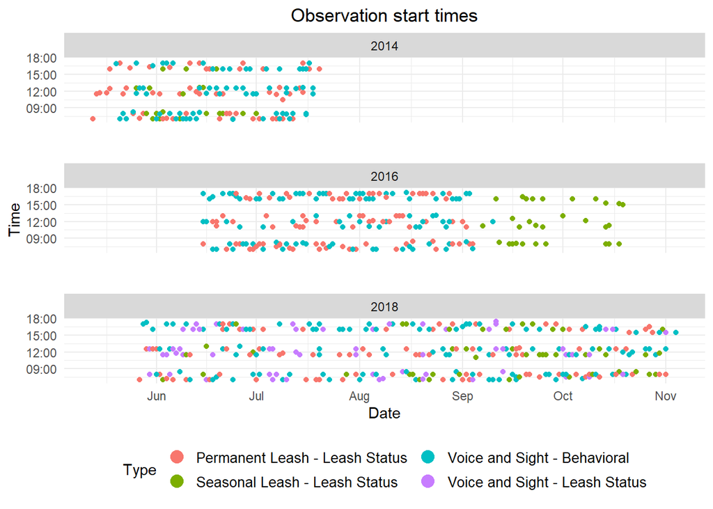

Figure 3.2: Start time for observations sessions plotted across months for each monitoring year. Each session was three hours long.

```r
vp_data %>%
  distinct(sessionID, .keep_all = TRUE) %>%
  mutate(Type = paste(regulation_class, monitoring_type, sep = " - "),
         start = as.POSIXct(format(timeStart, format = "%H:%M"), format = "%H:%M"),
         end = as.POSIXct(format(timeEnd, format = "%H:%M"), format = "%H:%M"),
         year = year(sessionDate),
         month = month(sessionDate),
         CommonDate = as.Date(paste0("2000-", format(sessionDate, "%j")), "%Y-%j")) %>%
  ggplot(., aes(x = CommonDate, y = start, group = Type, color = Type)) +
  geom_point() +
  facet_wrap(~ year, nrow = 3) +
  theme_minimal() +
  xlab("Date") +
  ylab("Time") +
  labs(title = "Observation start times") +
  theme(
    plot.title = element_text(hjust = 0.5),
    panel.spacing = unit(2, "lines"),
    legend.position = "bottom",
    legend.text = element_text(size = 10),
    strip.background = element_rect(fill="grey85", linetype = "blank")) +
  guides(col = guide_legend(nrow = 2, override.aes = list(size = 4)))
```

#### Summarized Tabular View

```r
vp_data %>%
  distinct(sessionID, .keep_all = TRUE) %>%
  mutate(Type = paste(regulation_class, monitoring_type, sep = " - ")) %>%
  group_by(year, Type, timePeriod) %>%
  summarise(Count = n()) %>%
  spread(key = timePeriod, value = Count) %>%
  group_by(year, Type) %>%
  mutate(total = sum(AM, `Mid-day`, PM)) %>%
  kable("html", escape = F,
        caption = "Number of sessions by type and period of day.",
        col.names = c("Year", "Session Type", "AM", "Mid-day", "PM", "Total")) %>%
  kable_styling("hover", full_width = F, position = "left") %>%
  collapse_rows(columns = 1, valign = "top")
```

Table 3.1: Number of sessions by type and period of day.

| Year | Session Type | AM | Mid-day | PM | Total |
| --- | --- | --- | --- | --- | --- |
| 2014 | Permanent Leash - Leash Status | 22 | 23 | 22 | 67 |
|  | Seasonal Leash - Leash Status | 12 | 5 | 4 | 21 |
|  | Voice and Sight - Behavioral | 25 | 22 | 18 | 65 |
| 2016 | Permanent Leash - Leash Status | 34 | 31 | 30 | 95 |
|  | Seasonal Leash - Leash Status | 10 | 10 | 10 | 30 |
|  | Voice and Sight - Behavioral | 29 | 26 | 43 | 98 |
| 2018 | Permanent Leash - Leash Status | 32 | 28 | 21 | 81 |
|  | Seasonal Leash - Leash Status | 17 | 17 | 11 | 45 |
|  | Voice and Sight - Behavioral | 35 | 32 | 44 | 111 |
|  | Voice and Sight - Leash Status | 19 | 23 | 19 | 61 |

#### Detailed Tabular View

```r
vp_data %>%
  #distinct(sessionID, .keep_all = TRUE) %>%
  mutate(visitors_observed = !is.na(visitorID)) %>%
  group_by(year, Type, SiteName, sessionDate) %>%
  summarise(Count = sum(visitors_observed)) %>%
  #spread(key = timePeriod, value = Count) %>%
  #group_by(year, Type) %>%
  #mutate(total = sum(AM, `Mid-day`, PM)) %>%
  kable(caption = "Number of visitor groups observed by individual observation session.",
        col.names = c("Year", "Type", "Location", "Date", "Visitor Groups")) %>%
  kable_styling("hover", full_width = F, position = "left") %>%
  scroll_box(width = "100%", height = "500px")
```

Table 3.2: Number of visitor groups observed by individual observation session.

| Year | Type | Location | Date | Visitor Groups |
| --- | --- | --- | --- | --- |
| 2014 | Permanent Leash - Leash Status | Boulder Creek Path - Foothills | 2014-06-09 | 5 |
| 2014 | Permanent Leash - Leash Status | Boulder Creek Path - Foothills | 2014-06-10 | 2 |
| 2014 | Permanent Leash - Leash Status | Boulder Creek Path - Foothills | 2014-07-04 | 2 |
| 2014 | Permanent Leash - Leash Status | Buckingham Park | 2014-05-14 | 0 |
| 2014 | Permanent Leash - Leash Status | Buckingham Park | 2014-05-18 | 3 |
| 2014 | Permanent Leash - Leash Status | Buckingham Park | 2014-05-25 | 1 |
| 2014 | Permanent Leash - Leash Status | Buckingham Park | 2014-05-26 | 1 |
| 2014 | Permanent Leash - Leash Status | Buckingham Park | 2014-06-03 | 2 |
| 2014 | Permanent Leash - Leash Status | Buckingham Park | 2014-07-18 | 0 |
| 2014 | Permanent Leash - Leash Status | Cowdrey Draw | 2014-06-07 | 0 |
| 2014 | Permanent Leash - Leash Status | Cowdrey Draw | 2014-06-13 | 1 |
| 2014 | Permanent Leash - Leash Status | Cowdrey Draw | 2014-07-01 | 0 |
| 2014 | Permanent Leash - Leash Status | Cowdrey Draw | 2014-07-10 | 1 |
| 2014 | Permanent Leash - Leash Status | Dakota Ridge Trail | 2014-06-11 | 18 |
| 2014 | Permanent Leash - Leash Status | Dakota Ridge Trail | 2014-07-08 | 8 |
| 2014 | Permanent Leash - Leash Status | Dakota Ridge Trail | 2014-07-18 | 16 |
| 2014 | Permanent Leash - Leash Status | E.M. Greenman | 2014-06-05 | 1 |
| 2014 | Permanent Leash - Leash Status | East Boulder - Teller Lake ADA | 2014-06-04 | 2 |
| 2014 | Permanent Leash - Leash Status | Eldorado Canyon Trail | 2014-05-22 | 0 |
| 2014 | Permanent Leash - Leash Status | Eldorado Canyon Trail | 2014-06-06 | 0 |
| 2014 | Permanent Leash - Leash Status | Foothills South/Old Kiln | 2014-05-15 | 7 |
| 2014 | Permanent Leash - Leash Status | Foothills South/Old Kiln | 2014-06-20 | 2 |
| 2014 | Permanent Leash - Leash Status | Foothills South/Old Kiln | 2014-07-12 | 7 |
| 2014 | Permanent Leash - Leash Status | Foothills South/Old Kiln | 2014-07-16 | 3 |
| 2014 | Permanent Leash - Leash Status | Fowler Trail | 2014-06-24 | 2 |
| 2014 | Permanent Leash - Leash Status | Fowler Trail | 2014-07-09 | 1 |
| 2014 | Permanent Leash - Leash Status | Fowler Trail | 2014-07-10 | 0 |
| 2014 | Permanent Leash - Leash Status | Green Mountain West Ridge/Green Bear | 2014-05-16 | 2 |
| 2014 | Permanent Leash - Leash Status | High Plains Trail | 2014-05-28 | 0 |
| 2014 | Permanent Leash - Leash Status | High Plains Trail | 2014-06-01 | 1 |

[output cut: 637 more lines]

### 3.2.2 Visitor Group Composition

Every observation component included collection of basic visitor group information including group size and activity type along with information about the number of dogs.

Looking at activity distribution we can see that hikers were the most frequently observed visitor groups, followed by runners. This information is presented both in bar char (Figure 3.3) and tabular form (Table 3.3) below.

#### Bar Chart

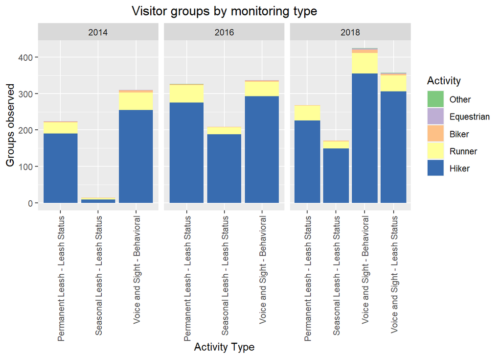

Figure 3.3: The number of visitor groups observed within each monitoring type for each year.

```r
vp_data %>%
  filter(!is.na(visitorID)) %>%
  mutate(activityPeople = factor(activityPeople, levels = rev(c("Hiker", "Runner", "Biker", "Equestrian", "Other")))) %>%
  ggplot(., aes(Type)) +
  geom_bar(aes(fill = activityPeople)) +
  #geom_text(stat = 'count', aes(label = ..count..), vjust = -.4, size = 3) +
  facet_wrap(. ~ year, scales = "free_x") +
  #scale_fill_discrete(name = "Monitoring Type",
  #                    labels = c("Voice & Sight", "Leash Required", "Seasonal Leash")) +
  xlab("Activity Type") +
  ylab("Groups observed") +
  labs(title = "Visitor groups by monitoring type",
       fill = "Activity") +
  theme(plot.title = element_text(hjust = 0.5),
        plot.subtitle = element_text(hjust = 0.5),
        axis.text.x=element_text(angle=90,hjust=1, vjust = 0.5)) +
  scale_fill_brewer(type = "qual", palette = "Accent")
```

```r
# vp_data %>%
#   group_by(Year, Type, Activity) %>%
#   summarise(n = n()) %>%
#   kable("html", escape = F,
#         caption = "Number of visitor groups observed by activity type",
#         col.names = c("Year", "Session Type", "Activity", "Visitor Groups")) %>%
#   kable_styling("hover", full_width = F, position = "left")
```

#### Tabular

```r
vp_data %>%
  filter(!is.na(visitorID)) %>%
  mutate(activityPeople = factor(activityPeople, levels = (c("Hiker", "Runner", "Biker", "Equestrian", "Other")))) %>%
  rename(Year = year) %>%
  group_by(Year, Type, activityPeople) %>%
  summarise(n = n()) %>%
  spread(key = activityPeople, value = n, fill = 0) %>%
  kable(caption = "Number of visitor groups observed by session type and monitoring year") %>%
  kable_styling(full_width = F, position = "left") %>%
  collapse_rows(columns = 1, valign = "top")
```

Table 3.3: Number of visitor groups observed by session type and monitoring year

| Year | Type | Hiker | Runner | Biker | Equestrian | Other |
| --- | --- | --- | --- | --- | --- | --- |
| 2014 | Permanent Leash - Leash Status | 190 | 31 | 2 | 1 | 0 |
|  | Seasonal Leash - Leash Status | 9 | 4 | 1 | 0 | 0 |
|  | Voice and Sight - Behavioral | 255 | 48 | 6 | 1 | 0 |
| 2016 | Permanent Leash - Leash Status | 275 | 48 | 2 | 0 | 1 |
|  | Seasonal Leash - Leash Status | 188 | 20 | 1 | 0 | 0 |
|  | Voice and Sight - Behavioral | 293 | 40 | 3 | 1 | 0 |
| 2018 | Permanent Leash - Leash Status | 226 | 41 | 1 | 0 | 0 |
|  | Seasonal Leash - Leash Status | 149 | 20 | 2 | 0 | 0 |
|  | Voice and Sight - Behavioral | 355 | 57 | 9 | 3 | 1 |
|  | Voice and Sight - Leash Status | 306 | 44 | 4 | 2 | 1 |

Looking at the distribution of the number of off-leash dogs per visitor group by year, we can see that the majority of visitor groups have one or two dogs in the group.

```r
vs %>%
  select(year, visitorID, starts_with("numDog")) %>%
  filter(!is.na(visitorID)) %>%
  distinct(visitorID, .keep_all = TRUE) %>%
  mutate(Leashed = numDog_leashTag + numDog_leashNoTag + numDog_leashUnsure,
         Off_Leash = numDog_offTag + numDog_offNoTag + numDog_offUnsure,
         All_Dogs = Leashed + Off_Leash) %>%
  group_by(year, Off_Leash) %>%
  summarise(visitor_groups = n(),
            dogs = sum(Off_Leash)) %>%
  mutate(percent_groups = paste0(round(visitor_groups / sum(visitor_groups) * 100, 0), "%"),
         percent_dogs = paste0(round(dogs / sum(dogs) * 100, 0), "%")) %>%
  select(year, Off_Leash, visitor_groups, percent_groups, dogs, percent_dogs) %>%
  kable(caption = "Distribution of the number of off-leash dogs per visitor group.",
        col.names = c("Year", "Dogs in group", "Frequency", "Percent", "Frequency", "Percent"),
        align = 'lcrrrr',
        escape = FALSE) %>%
  kable_styling(full_width = F, position = "left") %>%
  collapse_rows(columns = 1, valign = "top") %>%
  add_header_above(c(" " = 2, "Visitor Groups" = 2, "Dogs" = 2))
```

Table 3.4: Distribution of the number of off-leash dogs per visitor group.

| Year | Dogs in group | Visitor Groups Frequency | Visitor Groups Percent | Dogs Frequency | Dogs Percent |
| --- | --- | --- | --- | --- | --- |
| 2014 | 1 | 236 | 76% | 236 | 59% |
|  | 2 | 60 | 19% | 120 | 30% |
|  | 3 | 11 | 4% | 33 | 8% |
|  | 4 | 3 | 1% | 12 | 3% |
| 2016 | 1 | 260 | 77% | 260 | 61% |
|  | 2 | 67 | 20% | 134 | 32% |
|  | 3 | 10 | 3% | 30 | 7% |
| 2018 | 1 | 343 | 81% | 343 | 66% |
|  | 2 | 72 | 17% | 144 | 28% |
|  | 3 | 9 | 2% | 27 | 5% |
|  | 4 | 1 | 0% | 4 | 1% |

## 3.3 Voice and Sight Compliance

Compliance with Voice and Sight regulations can broadly be broken into two categories of measures. The first are categorical measures, which are measures that can directly assessed and are unambiguously explicit in their compliance outcome. Categorical measures were evaluated by constructing logic evaluations that look for the presence or absence of certain values that would indicate non-compliance. For example, IF a visitor group has 1 or more off-leash dogs with no tag THEN the group is non-compliant.

The second type of compliance measures are the contextual measures, which are the behaviors assessed when a dog interacts with another group (people, dogs, wildlife, livestock) on the trail or when the guardian issues a command to the dog that requires a behavioral response. Contextual measures were evaluated once data collection was completed by assembling a panel of staff that included at least one project researcher, Voice and Sight program staff, and a law enforcement ranger. When evaluating contextual measures, staff would consider the type and sequence of behaviors displayed by the dog under observation, the response of the “other” group, and the response by the guardian (e.g. control attempt). Following is a list of the categorical and contextual measures that have been reported for the Voice and Sight component.

**Categorical**

- Tag display
- Dog to guardian ratio
- Within sight
- Not entering closed areas
- Excrement pickup and removal

**Contextual**

- Person and dog interactions
  - Group-level stats
  - Event-level stats
- Voice commands

### 3.3.2 Categorical Measures

#### 3.3.2.1 Tag display

For tag display, staff observed between 310 and 425 visitor groups depending on the year as part of the Voice and Sight component. A visitor party was considered compliant if all off-leash dogs in the party had a tag visibly displayed. A visitor party was considered Non-Compliant if at least one off-leash dog in the party did not have a tag visibly displayed. A visitor party was considered unsure if at least one off-leash dog had unsure tag display (and the party did not also include a no tag display dog).

```r
vs %>%
  select(year, visitorID, starts_with("numDog")) %>%
  filter(!is.na(visitorID)) %>%
  distinct(visitorID, .keep_all = TRUE) %>%
  mutate(tag_compliance = if_else(numDog_offNoTag >= 1, "NonCompliant",
                                     if_else(numDog_offUnsure >= 1, "Unsure", "Compliant"))) %>%
  group_by(year, tag_compliance) %>%
  summarise(total = n()) %>%
  mutate(percent = paste0(round(total / sum(total) * 100, 0),"%")) %>%
  pivot_wider(names_from = tag_compliance, values_from = c("total", "percent")) %>%
  select(year, total_Compliant, percent_Compliant, total_NonCompliant, percent_NonCompliant, total_Unsure, percent_Unsure) %>%
  kable(caption = "Visitor group compliance with tag display for all off-leash dogs.",
        col.names = c("Year", "Frequency", "Percent", "Frequency", "Percent", "Frequency", "Percent"),
        align = 'lrrrrrr') %>%
  kable_styling(full_width = F, position = "left") %>%
  add_header_above(c(" " = 1, "Compliant" = 2, "Non Compliant" = 2, "Unsure" = 2))
```

Table 3.5: Visitor group compliance with tag display for all off-leash dogs.

| Year | Compliant Frequency | Compliant Percent | Non Compliant Frequency | Non Compliant Percent | Unsure Frequency | Unsure Percent |
| --- | --- | --- | --- | --- | --- | --- |
| 2014 | 215 | 69% | 62 | 20% | 33 | 11% |
| 2016 | 190 | 56% | 67 | 20% | 80 | 24% |
| 2018 | 348 | 82% | 53 | 12% | 24 | 6% |

We can also view tag display for off leash dogs by individual dog. Because the majority of visitor groups only had one dog with them (Table 3.4) the percentage for tag display by individual dog (Table 3.6) are similar to overall group level compliance.

```r
vs %>%
  select(year, visitorID, starts_with("numDog")) %>%
  filter(!is.na(visitorID)) %>%
  distinct(visitorID, .keep_all = TRUE) %>%
  # mutate(tag_compliance = if_else(numDog_offNoTag >= 1, "Non-Compliant",
  #                                    if_else(numDog_offUnsure >= 1, "Unsure", "Compliant"))) %>%
  group_by(year) %>%
  summarise(Compliant = sum(numDog_offTag),
            NonCompliant = sum(numDog_offNoTag),
            Unsure = sum(numDog_offUnsure)) %>%
  mutate(total = Compliant + NonCompliant + Unsure,
         Compliant_percent = paste0(round(Compliant / total * 100, 0),"%"),
         NonCompliant_percent = paste0(round(NonCompliant / total * 100, 0),"%"),
         Unsure_percent = paste0(round(Unsure / total * 100, 0),"%")) %>%
  select(year, Compliant, Compliant_percent, NonCompliant, NonCompliant_percent, Unsure, Unsure_percent) %>%
  #pivot_wider(names_from = year, values_from = c("total", "percent")) %>%
  kable(caption = "Individual dog compliance with tag display for for all off-leash dogs",
        col.names = c("Year", "Frequency", "Percent", "Frequency", "Percent", "Frequency", "Percent"),
        align = 'lrrrrrr') %>%
  kable_styling(full_width = F, position = "left") %>%
  add_header_above(c(" " = 1, "Compliant" = 2, "Non Compliant" = 2, "Unsure" = 2))
```

Table 3.6: Individual dog compliance with tag display for for all off-leash dogs

| Year | Compliant Frequency | Compliant Percent | Non Compliant Frequency | Non Compliant Percent | Unsure Frequency | Unsure Percent |
| --- | --- | --- | --- | --- | --- | --- |
| 2014 | 286 | 71% | 72 | 18% | 43 | 11% |
| 2016 | 246 | 58% | 78 | 18% | 100 | 24% |
| 2018 | 431 | 83% | 57 | 11% | 30 | 6% |

#### 3.3.2.2 Dog to guardian ratio

Compliance with the requirement for no more than two off-leash dogs per guardian looks at the number of groups with three or more off-leash dogs and assesses whether or not there were enough adult guardians present (Table 3.7). Because the observer cannot attribute guardianship of dogs to specific people in the visitor group, compliance was evaluated by comparing the ratio of off-leash dogs to number of adult persons in the visitor group, which was recorded as a separate variable on the data sheet. The number of groups with more than two off-leash dogs is small to begin with (see Table 3.4) so compliance with this measure is high (98% for greater) when considering the number of visitor groups observed (with at least one off-leash dog). If we subset the observations to include only groups that had three or more off-leash dogs, compliance ranges between 30% and 60%.

```r
vp_data %>%
  filter(Type == "Voice and Sight - Behavioral", !is.na(visitorID)) %>%
  mutate(more2dogs = if_else(Off_Leash > 2, TRUE, FALSE),
         violation = if_else(numDog_offMore2 == "Yes", TRUE, FALSE)) %>%
  group_by(year) %>%
  summarise(groups = n(),
            more2dogs = sum(more2dogs),
            violation = sum(violation)) %>%
  group_by(year) %>%
  mutate(percent_all = percent((groups - violation) / groups, 0),
         percent_3off = percent((more2dogs - violation) / more2dogs, 0))%>%
  kable(caption = "Visitor group compliance with no more than two dogs off-leash per adult guardian.",
        col.names = c("Year", "Total", "> 2 dogs", "Violations", "All Groups", "> 2 dogs"),
        align = c("l", rep("r", 5))) %>%
  kable_styling(full_width = FALSE, position = "left") %>%
  add_header_above(c(" ", "Visitor Groups" = 3, "Percent Compliance" = 2))
```

Table 3.7: Visitor group compliance with no more than two dogs off-leash per adult guardian.

| Year | Visitor Groups Total | Visitor Groups > 2 dogs | Visitor Groups Violations | Percent Compliance All Groups | Percent Compliance > 2 dogs |
| --- | --- | --- | --- | --- | --- |
| 2014 | 310 | 14 | 7 | 98% | 50% |
| 2016 | 337 | 10 | 4 | 99% | 60% |
| 2018 | 425 | 10 | 7 | 98% | 30% |

#### 3.3.2.3 Within sight

The within sight measure was defined as whether or not the dog(s) in a visitor party are not within the immediate 360° field of view of the guardian(s) at all times. This measure does not assess if the guardian is actively looking at their dog(s) but rather if the dog(s) became physically obscured from the guardians position by vegetation or terrain. Compliance for this measure ranged between 93% and 99% for all three monitoring years (Table 3.8).

```r
vs %>%
  select(year, visitorID, ctrlOutOfSight) %>%
  filter(!is.na(visitorID)) %>%
  group_by(visitorID) %>%
  mutate(outOfSight = sum(ctrlOutOfSight == "Yes", na.rm = TRUE)) %>%
  distinct(visitorID, .keep_all = TRUE) %>%
  group_by(year) %>%
  summarise(visitor_groups = n(),
            out_sight = sum(outOfSight >= 1, na.rm = TRUE),
            compliance = paste0(round((visitor_groups - out_sight)/visitor_groups * 100, 0), "%")) %>%
  kable(caption = "Number and compliance outcomes with the out-of-sight regulation at the visitor group level.",
        col.names = c("Year", "Total", "Violation", "Compliance"),
        align = 'lrrr') %>%
  kable_styling(full_width = FALSE, position = "left") %>%
  add_header_above(c(" ", "Visitor Groups" = 2, " "))
```

Table 3.8: Number and compliance outcomes with the out-of-sight regulation at the visitor group level.

| Year | Visitor Groups Total | Visitor Groups Violation | Compliance |
| --- | --- | --- | --- |
| 2014 | 310 | 21 | 93% |
| 2016 | 337 | 8 | 98% |
| 2018 | 425 | 5 | 99% |

#### 3.3.2.4 Not entering closed areas

```r
vs %>%
  select(year, visitorID, ctrlEnterClosure) %>%
  filter(!is.na(visitorID), !is.na(ctrlEnterClosure)) %>%
  group_by(visitorID) %>%
  mutate(enterClosure = sum(ctrlEnterClosure == "Yes", na.rm = TRUE)) %>%
  distinct(visitorID, .keep_all = TRUE) %>%
  group_by(year) %>%
  summarise(visitor_groups = n(),
            enterClosure = sum(enterClosure >= 1, na.rm = TRUE),
            compliance = percent((visitor_groups - enterClosure)/visitor_groups, 0)) %>%
  kable(caption = "Number and compliance outcomes with the not entering closed areas regulation at the visitor group level.",
        col.names = c("Year", "Total", "Violation", "Compliance"),
        align = 'lrrr') %>%
  kable_styling(full_width = FALSE, position = "left") %>%
  add_header_above(c(" ", "Visitor Groups" = 2, " ")) %>%
  footnote("Only includes visitor groups that were adjacent to area closures")
```

Table 3.9: Number and compliance outcomes with the not entering closed areas regulation at the visitor group level.

| Year | Visitor Groups Total | Visitor Groups Violation | Compliance |
| --- | --- | --- | --- |
| 2014 | 23 | 1 | 96% |
| 2016 | 5 | 0 | 100% |
| 2018 | 29 | 2 | 93% |

Note:  
Only includes visitor groups that were adjacent to area closures

#### 3.3.2.5 Excrement pickup and removal

Excrement pickup and removal is not a part of the Voice and Sight code specifically but it was included since it is a general requirement for all dogs on open space properties. Dogs in the majority of visitor groups did not have any poop events while under observation but for those that did, compliance with the requirement for guardians to both bag and take the excrement with them ranged between 58% and 79%.

```r
vs %>%
  select(year, visitorID, numExcrement, pickUpExcrement, takeExcrement) %>%
  filter(!is.na(visitorID), numExcrement >= 1) %>%
  group_by(year, visitorID) %>%
  summarise(pickUp = sum(pickUpExcrement == "Yes", na.rm = TRUE),
            take = sum(takeExcrement == "Yes", na.rm = TRUE),
            compliant = pickUp >= 1 & pickUp == take) %>%
  group_by(year) %>%
  summarise(visitor_groups = n(),
            violations = sum(compliant),
            compliance = percent(sum(compliant)/visitor_groups, 0)) %>%
  kable(caption = "Number and compliance outcomes with the pick up and remove (take) dog excrement requirement at the visitor group level.",
        col.names = c("Year", "Total", "Violation", "Compliance"),
        align = 'lrrr') %>%
  kable_styling(full_width = FALSE, position = "left") %>%
  add_header_above(c(" ", "Visitor Groups" = 2, " ")) %>%
  footnote("Only includes visitor groups with dogs that had one or more poop events")
```

Table 3.10: Number and compliance outcomes with the pick up and remove (take) dog excrement requirement at the visitor group level.

| Year | Visitor Groups Total | Visitor Groups Violation | Compliance |
| --- | --- | --- | --- |
| 2014 | 26 | 18 | 69% |
| 2016 | 19 | 11 | 58% |
| 2018 | 28 | 22 | 79% |

Note:  
Only includes visitor groups with dogs that had one or more poop events

### 3.3.3 Contextual Measures

#### 3.3.3.1 Person and dog interactions

There are several variables that go into evaluating compliance outcomes for interactions between the dog(s) in the visitor group under observation and other visitor groups. To begin with, we must determine if there were any events, as not every visitor group observed necessarily had opportunities to interact with other visitor groups while under observation. For those groups that do have opportunities for interactions, the opportunities can be combination of other people, dogs, wildlife or livestock. When an opportunity was observed, it could either result in a *pass*, where the dog(s) under observation didn’t engage in behaviors of interest or it could result in an *interaction*, where behaviors of interest did take place. Determining whether or not an *interaction* event was non-compliant (violation) requires evaluation of additional context variables including behaviors for the dog(s) under observation, response behaviors from the other visitor group and finally voice or other control attempts by the dog guardian under observation. There are numerous options for how we could group all these variables together into a single table of compliance outcomes. However, while the results would all be technically correct based on the evaluative logic we think that trying to evaluate all the variables makes the results difficult to interpret in terms of generalization to what one might “see” when out on the trails. Therefore, we have broken down the analysis based on the following questions.

- What proportion of visitor groups had event opportunities while under observation?
  - How many visitor groups had a non-compliant dog behavior or guardian command attempt during an event?
- What is the breakdown of the types of event opportunities that were observed?
  - What proportion of these opportunities resulted in passes vs interactions?
  - What were the compliance outcomes by type of event opportunity and for those that were violations, what were the non-compliance reasons?

##### Group-level stats

**Groups with events**

We can begin by evaluating the first question *What proportion of visitor groups had event opportunities while under observation?* (Table 3.11)

```r
vs %>%
  filter(!is.na(visitorID)) %>%
  mutate(events = if_else(is.na(eventNum), "NoEvents", "Events")) %>%
  group_by(year, events) %>%
  summarise(total = n_distinct(visitorID)) %>%
  pivot_wider(names_from = events, values_from = total) %>%
  mutate(total = Events + NoEvents,
         percent = percent(Events / total, 0)) %>%
  select(year, total, Events, percent) %>%
  kable(caption = "Proportion of visitor groups with one or more events.",
        col.names = c("Year", "Total", "With Events", "Percent with Events")) %>%
  kable_styling(full_width = FALSE, position = "left") %>%
  add_header_above(c(" ", "Visitor Groups" = 2, " "))
```

Table 3.11: Proportion of visitor groups with one or more events.

| Year | Visitor Groups Total | Visitor Groups With Events | Percent with Events |
| --- | --- | --- | --- |
| 2014 | 310 | 176 | 57% |
| 2016 | 337 | 192 | 57% |
| 2018 | 425 | 197 | 46% |

**Behavioral compliance**

Next, we can look at group-level by evaluating first whether a group had an opportunities for events and if they did, were any of those events non-compliant, regardless of what the opportunity type was (Table 3.12). This is also the most stringent test as any non-compliant event for the group will result in an overall group-level evaluation of non-compliant. The two reasons (based on the monitoring methodology) that an event will evaluate to non-compliant is either that the dog(s) under observation engaged in a non-compliant behavior (e.g. aggression, chasing wildlife) or failed to respond to a command issued by the dog guardian (voice or alternate command). For the purposes of this report, we are using the following definitions when distinguishing between dog behaviors and guardian commands:

dog behavior –*the categorical behavior(s) exhibited by the dog under observation toward another visitor group, dog, livestock or wildlife*  
guardian command – *a verbal or alternative command issued by the dog guardian for the purpose of eliciting a change in behavior on the part of the dog*

These tables below, which have been separated for dog behaviors and guardian commands, give us the probability of observing a compliant or non-compliant event for a visitor group within an observation zone. We can start with the dog behavior table since conceptually, this measure is a little more straightforward than the guardian command measure. In the case of dog behaviors, so long as there were no non-compliant behaviors observed during an event, the event evaluates to compliant. Whether the dog was disinclined to engage in the behavior on their own or the guardian intervened with a command before the dog carried out the behavior (resulting in an avoidance of the behavior), what matters for the dog behavior measure is that the behavior was avoided.

```r
vs %>%
  mutate(events = if_else(is.na(eventNum), "No Events", "Events")) %>%
  filter(!is.na(visitorID), oppInteract == "Pass" | oppInteract == "Interaction") %>%
  group_by(visitorID) %>%
  mutate(group_compliance = case_when("Non-Compliant" %in% behavior_compliance ~ "Non-Compliant",
                                      "Compliant" %in% behavior_compliance ~ "Compliant",
                                      events == "No Events" | is.na(oppInteract) ~ "No Behavioral Events"),
         group_compliance = factor(group_compliance, levels = c("Compliant", "Non-Compliant", "No Behavioral Events"))) %>%
  select(visitorID, year, events, group_compliance, behavior_compliance, command_compliance, oppInteract) %>%
  group_by(year, group_compliance) %>%
  summarise(total = n_distinct(visitorID)) %>%
  group_by(year) %>%
  mutate(percent = percent(total /  sum(total), 1)) %>%
  select(-total) %>%
  pivot_wider(names_from = group_compliance, values_from = percent) %>%
  kable(caption = "Behavioral compliance outcomes for visitor groups that had at least one event opportunity.",
        col.names = c("Year", "Compliant", "Noncompliant")) %>%
  kable_styling(full_width = FALSE, position = "left")
```

Table 3.12: Behavioral compliance outcomes for visitor groups that had at least one event opportunity.

| Year | Compliant | Noncompliant |
| --- | --- | --- |
| 2014 | 81.1% | 18.9% |
| 2016 | 98.4% | 1.6% |
| 2018 | 99.4% | 0.6% |

**Command compliance**

Evaluating guardian commands is analytically similar to evaluating dog behaviors but has caveat that commands can only be evaluated *when* they are given. Unlike dog behavior, were any visitor group that had at least one event opportunity could be evaluated on the dog behavior compliance measure, not all visitor groups necessarily issued a command when one or more events occurred (Table 3.13). Therefore, we need to add an additional category for *No Command Issued*, indicating that there were event opportunities for the visitor group under observation but they never issued any commands that could be evaluated for compliance (i.e. successful dog response). The fact that no command was issued when one or more events occurred for a visitor group should not be interpreted as any level of evaluation on whether or not a command should have been issued. To be clear, this table is an evaluation of what **IS** and not what **SHOULD BE**.

```r
vs %>%
  filter(!is.na(visitorID), oppInteract == "Pass" | oppInteract == "Interaction") %>%
  mutate(events = if_else(is.na(eventNum), "No Events", "Events")) %>%
  group_by(visitorID) %>%
  mutate(group_compliance = case_when("Non-Compliant" %in% command_compliance ~ "Non-Compliant",
                                      "Compliant" %in% command_compliance ~ "Compliant",
                                      events == "Events" & is.na(command_compliance) ~ "No Command Issued",
                                      events == "No Events" ~ "No Command Events"),
         group_compliance = factor(group_compliance, levels = c("Compliant", "Non-Compliant", "No Command Issued", "No Command Events"))) %>%
  select(visitorID, year, group_compliance, behavior_compliance, command_compliance, oppInteract) %>%
  group_by(year, group_compliance) %>%
  summarise(total = n_distinct(visitorID)) %>%
  group_by(year) %>%
  mutate(percent = percent(total /  sum(total), 1)) %>%
  select(-total) %>%
  pivot_wider(names_from = group_compliance, values_from = percent) %>%
  kable(caption = "Voice recall compliance outcomes for visitor groups that had at least one event opportunity.",
        col.names = c("Year", "Compliant", "Noncompliant", "No Command Issued")) %>%
  kable_styling(full_width = FALSE, position = "left")
```

Table 3.13: Voice recall compliance outcomes for visitor groups that had at least one event opportunity.

| Year | Compliant | Noncompliant | No Command Issued |
| --- | --- | --- | --- |
| 2014 | 20.9% | 7.4% | 71.6% |
| 2016 | 16.1% | 5.7% | 78.1% |
| 2018 | 20.4% | 6.0% | 73.7% |

##### Event-level stats

To evaluate the types of events that do take place, we can ignore (filter out) the visitor groups that did not have any events and then categorize the event type based on what the opportunity was composed of. After categorizing the event, we looked at whether or not the event had a dog behavior violation, a guardian command violation, or both (Table 3.14). A couple of important things to remember are that commands could only be evaluated for compliance if they were given and that a single visitor group can have multiple events while under observation. Sometimes commands were given by the dog guardian in the absence of any opportunity. These were recorded as *Isolated command* events but are excluded from this table since they are not linked to specific opportunities (they are included in the Voice Recall section). There were also a number of events where the dog under observation approached the observer. These were categorized as *Observer* events to distinguish them from *Person* or *Person & Dog* events, which involved other visitor groups on the trail.

```r
vs %>%
  mutate(events = if_else(is.na(eventNum), "No Events", "Events")) %>%
  filter(!is.na(visitorID), events == "Events") %>%
  mutate(opp_type = case_when(Human >= 1 & Dog >= 1 ~ "Person & Dog",
                                Human >= 1 & Dog == 0 ~ "Person",
                                Human == 0 & Dog >= 1 ~ "Dog",
                                Observer >= 1 ~ "Observer", # observers ca
                                Equestrian >= 1 ~ "Person",
                                Wildlife >= 1 | Livestock >= 1 ~ "Wildlife/Livestock",
                                TRUE ~ "Isolated command"),
         opp_type = factor(opp_type, levels = c("Dog", "Person", "Person & Dog", "Wildlife/Livestock", "Observer", "Isolated command"))) %>%
  filter(opp_type != "Isolated command") %>%
  mutate(violation = case_when(oppInteract == "Pass" ~ "NoViolations_Pass" ,
                               command_compliance == "Non-Compliant" & behavior_compliance == "Non-Compliant" ~ "Violation_Both",
                               command_compliance == "Non-Compliant" ~ "Violation_Command",
                               behavior_compliance == "Non-Compliant" ~ "Violation_Behavior",
                               TRUE ~ "NoViolations"),
         violation = factor(violation, levels = c("NoViolations_Pass", "NoViolations", "Violation_Behavior",
                                                  "Violation_Command", "Violation_Both"))) %>%
  group_by(year, opp_type, violation) %>%
  summarise(total = n_distinct(visitorID)) %>%
  mutate(opp_n = sum(total)) %>%
  pivot_wider(., names_from = violation, values_from = total, values_fill = 0) %>%
  group_by(year, opp_type) %>%
  mutate(compliance = paste0(round((sum(NoViolations_Pass + NoViolations) / sum(opp_n)) * 100), "%")) %>%
  select(-opp_n) %>%
  kable(caption = "Frequency of events by opportunity type and compliance outcomes.",
        col.names = c("Year", "Opportunity", "Pass", "Interaction", "Behavior", "Command", "Both", "Compliance"),
        align = 'llrrrrrr') %>%
  kable_styling(full_width = FALSE, position = "left") %>%
  collapse_rows(columns = c(1), valign = "top") %>%
  add_header_above(c(" " = 2, "No Violation" = 2, "Violation" = 3, " "))
```

Table 3.14: Frequency of events by opportunity type and compliance outcomes.

| Year | Opportunity | No Violation Pass | No Violation Interaction | Violation Behavior | Violation Command | Violation Both | Compliance |
| --- | --- | --- | --- | --- | --- | --- | --- |
| 2014 | Dog | 7 | 16 | 5 | 3 | 0 | 74% |
|  | Person | 101 | 12 | 3 | 0 | 1 | 97% |
|  | Person & Dog | 11 | 8 | 8 | 1 | 1 | 66% |
|  | Wildlife/Livestock | 3 | 2 | 5 | 0 | 2 | 42% |
|  | Observer | 12 | 5 | 8 | 1 | 1 | 63% |
| 2016 | Dog | 1 | 0 | 0 | 0 | 0 | 100% |
|  | Person | 129 | 37 | 0 | 2 | 0 | 99% |
|  | Person & Dog | 34 | 28 | 1 | 3 | 0 | 94% |
|  | Wildlife/Livestock | 2 | 1 | 1 | 0 | 1 | 60% |
|  | Observer | 1 | 8 | 0 | 2 | 1 | 75% |
| 2018 | Dog | 0 | 1 | 0 | 0 | 0 | 100% |
|  | Person | 96 | 15 | 0 | 0 | 0 | 100% |
|  | Person & Dog | 26 | 27 | 0 | 2 | 0 | 96% |
|  | Wildlife/Livestock | 1 | 0 | 1 | 0 | 0 | 50% |
|  | Observer | 5 | 22 | 0 | 7 | 0 | 79% |

#### 3.3.3.2 Voice commands

The event-level stats above (Table 3.14 included voice commands that were considered to be recall events and whether or not those resulted in a noncompliant event. We can evaluate overall visitor group compliance for recall commands by considering whether or not any of the recall commands issued by a group were noncompliant. If they were, then the visitor group was considered to be noncompliant on the voice recall measure (Table 3.15).

```r
vs %>%
  filter(!is.na(visitorID), command_type == "recall") %>%
  group_by(visitorID) %>%
  mutate(group_compliance = case_when("Non-Compliant" %in% command_compliance ~ "Violation",
                                      "Compliant" %in% command_compliance ~ "noViolation")) %>%
  group_by(year, group_compliance) %>%
  summarise(count = n_distinct(visitorID)) %>%
  pivot_wider(names_from = group_compliance, values_from = count) %>%
  mutate(total = noViolation + Violation,
         noViolation_pct = percent(noViolation / total, 0),
         Violation_pct = percent(Violation / total, 0)) %>%
  select(year, noViolation, noViolation_pct, Violation, Violation_pct) %>%
  kable(caption = "Visitor group compliance with successful recall for all recall commands issued.",
        col.names = c("Year", "Frequency", "Percent", "Frequency", "Percent")) %>%
  kable_styling(full_width = FALSE, position = "left") %>%
  add_header_above(c(" ", "Compliant" = 2, "Noncompliant" = 2))
```

Table 3.15: Visitor group compliance with successful recall for all recall commands issued.

| Year | Compliant Frequency | Compliant Percent | Noncompliant Frequency | Noncompliant Percent |
| --- | --- | --- | --- | --- |
| 2014 | 44 | 77% | 13 | 23% |
| 2016 | 17 | 63% | 10 | 37% |
| 2018 | 43 | 78% | 12 | 22% |

However, there are other types of commands or spoken exchanges between guardians and dogs, which may or may not be intended as recall attempts on the part of the guardian. Table 3.16 below shows compliance rates broken out by year, command type, and the type of opportunity that was present when the guardian issued a command.

```r
vs %>%
  filter(!is.na(visitorID), !is.na(command_compliance)) %>%
  mutate(opp_type = case_when(oppInteract == "Pass" ~ "Pass",
                              oppInteract == "Interaction" ~ "Interaction",
                              TRUE ~ "Isolated"),
         opp_type = factor(opp_type, levels = c("Pass", "Interaction", "Isolated"))) %>%
  select(year, visitorID, oppInteract, opp_type, command_compliance, command_type) %>%
  group_by(visitorID, command_type, opp_type) %>%
  mutate(group_compliance = if_else("Non-Compliant" %in% command_compliance, "Violation", "No Violation")) %>%
  group_by(year, command_type, opp_type, group_compliance) %>%
  summarise(count = n_distinct(visitorID)) %>%
  ungroup() %>%
  pivot_wider(names_from = group_compliance, values_from = count, values_fill = 0) %>%
  mutate(total = `No Violation` + Violation,
         compliance_rate = paste0(round(`No Violation` / total * 100, 0),"%")) %>%
  select(-total) %>%
  kable(caption = "Visitor group compliance for all commands issued by opportunity type.",
        col.names = c("Year", "Command Type", "Opportunity", "No Violation", "Violation", "Compliance"),
        align = 'lllrrr') %>%
  kable_styling(full_width = FALSE, position = "left") %>%
  collapse_rows(columns = 1:2, valign = "top")
```

Table 3.16: Visitor group compliance for all commands issued by opportunity type.

| Year | Command Type | Opportunity | No Violation | Violation | Compliance |
| --- | --- | --- | --- | --- | --- |
| 2014 | other | Pass | 7 | 1 | 88% |
|  |  | Interaction | 13 | 5 | 72% |
|  |  | Isolated | 11 | 5 | 69% |
|  | recall | Pass | 3 | 1 | 75% |
|  |  | Interaction | 14 | 4 | 78% |
|  |  | Isolated | 31 | 9 | 78% |
| 2016 | other | Pass | 7 | 1 | 88% |
|  |  | Interaction | 10 | 2 | 83% |
|  |  | Isolated | 1 | 0 | 100% |
|  | recall | Pass | 6 | 1 | 86% |
|  |  | Interaction | 10 | 9 | 53% |
|  |  | Isolated | 1 | 0 | 100% |
| 2018 | other | Pass | 8 | 0 | 100% |
|  |  | Interaction | 10 | 1 | 91% |
|  |  | Isolated | 16 | 0 | 100% |
|  | recall | Pass | 5 | 1 | 83% |
|  |  | Interaction | 14 | 8 | 64% |
|  |  | Isolated | 26 | 3 | 90% |

## 3.4 Leash Status

In addition to conducting behavioral observation for Voice and Sight trail, staff also conducted observations on leash and tag status on all trails that allowed dogs. This component differed from the behavioral observation in that it was conducted as a simple line transect across the trail and did not include any coding of behaviors. Rather, it was designed to collect a census of all visitor groups with at least one dog, including a breakdown of group size, activity and the leash and tag status of any dogs in the group.

```r
vp_data %>%
  select(year, Type, visitorID, starts_with("numDog"), tag_leash_compliance, regulation_class) %>%
  filter(!is.na(visitorID), Type != "Voice and Sight - Behavioral") %>%
  group_by(regulation_class, year, tag_leash_compliance) %>%
  summarise(frequency = n()) %>%
  #mutate(percent = percent(frequency / sum(frequency), 0)) %>%
  pivot_wider(names_from = tag_leash_compliance, values_from = frequency) %>%
  rowwise() %>%
  mutate(total = sum(Compliant, NonCompliant, Unsure, na.rm = TRUE),
         comp_pct = percent(Compliant / total, 0),
         noncomp_pct = percent(NonCompliant / total, 0),
         unsure_pct = percent(Unsure / total, 0)) %>%
  select(regulation_class, year, Compliant, comp_pct, NonCompliant, noncomp_pct, Unsure, unsure_pct) %>%
  kable(caption = "Visitor group compliance with leash and tag regulations for all groups with at least one dog.",
        col.names = c("Type", "Year", "Frequency", "Percent", "Frequency", "Percent", "Frequency", "Percent"),
        align = 'llrrrrrr',
        escape = FALSE) %>%
  kable_styling(full_width = FALSE, position = "left") %>%
  collapse_rows(columns = c(1), valign = "top") %>%
  add_header_above(c(" " = 2,  "Compliant" = 2, "Noncompliant" = 2, "Unsure" = 2))
```

Table 3.17: Visitor group compliance with leash and tag regulations for all groups with at least one dog.

| Type | Year | Compliant Frequency | Compliant Percent | Noncompliant Frequency | Noncompliant Percent | Unsure Frequency | Unsure Percent |
| --- | --- | --- | --- | --- | --- | --- | --- |
| Permanent Leash | 2014 | 187 | 83% | 37 | 17% | NA | NA |
|  | 2016 | 248 | 76% | 78 | 24% | NA | NA |
|  | 2018 | 214 | 80% | 54 | 20% | NA | NA |
| Seasonal Leash | 2014 | 8 | 57% | 6 | 43% | NA | NA |
|  | 2016 | 130 | 62% | 79 | 38% | NA | NA |
|  | 2018 | 96 | 56% | 75 | 44% | NA | NA |
| Voice and Sight | 2018 | 317 | 89% | 23 | 6% | 17 | 5% |

While Table 3.17 shows that compliance differs among regulation class, we can also look at ranges of compliance within a regulations class. We started by filtering out any locations with fewer than 10 total observations within a given year to account for locations with small sample sizes. Plotting compliance rates using a boxplot can give us a sense of both the range of compliance rates across trails as well as how those compliance rates are distributed within that range (Figure 3.4). Permanent leash regulation trails have a median compliance of 86% but also have a wide range of around 57% to 100% (excluding the two outliers). Voice and Sight trails have a similar median compliance at around 90% but a narrower range of around 71% to 100%. Seasonal leash regulation trails have the lowest compliance rates with a median of 57% and a range of 41% to 73%.

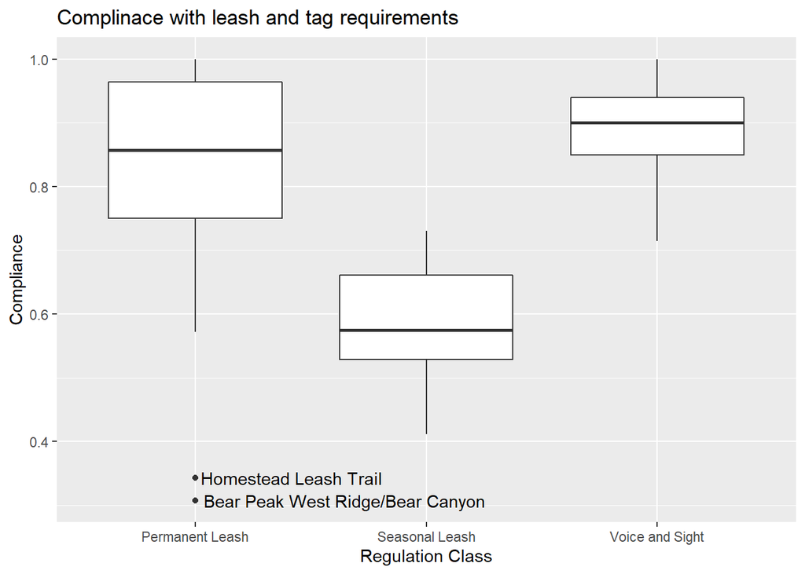

Figure 3.4: Compliance ranges and distribution by regulation class

```r
is_outlier <- function(x) {
  return(x < quantile(x, 0.25) - 1.5 * IQR(x) | x > quantile(x, 0.75) + 1.5 * IQR(x))
}


vp_data %>%
  select(year, Type, SiteName, visitorID, tag_leash_compliance, regulation_class) %>%
  filter(!is.na(visitorID), Type != "Voice and Sight - Behavioral") %>%
  group_by(SiteName, regulation_class, year) %>%
  mutate(sample_size = n()) %>%
  filter(sample_size >= 10) %>%
  group_by(SiteName, regulation_class, year) %>%
  summarise(compliance = sum(tag_leash_compliance == "Compliant") / n()) %>%
  group_by(regulation_class) %>%
  mutate(outlier = ifelse(is_outlier(compliance), SiteName, as.character(NA)),
         year = factor(year)) %>%
  ggplot(., aes(x = regulation_class, y = compliance)) +
  geom_boxplot() +
  #facet_wrap(. ~ regulation_class) +
  geom_text(aes(label = outlier), na.rm = TRUE, hjust = -.03) +
  labs(title = "Complinace with leash and tag requirements") +
  xlab("Regulation Class") +
  ylab("Compliance")
```

While compliance is dependent on the visitor group following the applicable leash and tag regulations for all dogs in their group we can also look at the proportional breakout by individual dogs for leash and tag status. Table 3.18 below can start to give us a sense of the interaction among regulation class (Type), leash status and tag status. For example, for permanent leash required trails, between 10% and 12% of off leash dogs had a Voice and Sight tag while between 5% and 8% of off leash dogs did not have a tag. Seasonal leash trails on the other hand had much more variability over the three monitoring years for whether off leash dogs were more likely to have a Voice and Sight tag of not. The most recent data from the 2018 cycle suggests that for off leash dogs, there were about 4 times (30%) as many dogs with a tag as those without (8%).

```r
vp_data %>%
  select(year, Type, visitorID, starts_with("numDog"), regulation_class) %>%
  filter(!is.na(visitorID), Type != "Voice and Sight - Behavioral") %>%
  group_by(regulation_class, year) %>%
  summarize(Leash_Tag = sum(numDog_leashTag),
            Leash_NoTag = sum(numDog_leashNoTag),
            Leash_Unsure = sum(numDog_leashUnsure),
            Off_Tag = sum(numDog_offTag),
            Off_NoTag = sum(numDog_offNoTag),
            Off_Unsure = sum(numDog_offUnsure)) %>%
  pivot_longer(cols = (3:8), names_to = "Status", values_to = "Dogs") %>%
  group_by(year, regulation_class) %>%
  mutate(Dogs_pct = percent(Dogs / sum(Dogs), 0)) %>%
  select(-Dogs) %>%
  # mutate(Leash = if_else(grepl("Leash", Status), "Leash", "OffLeash"),
  #        Status = gsub("([[:alpha:]])([[:upper:]])", "\\1 \\2",
  #                      substr(Status, regexpr("_", Status) + 1, nchar(Status)))) %>%
  pivot_wider(names_from = Status, values_from = Dogs_pct) %>%
  kable(caption = "Proportion of all individual dogs observed by leash and tag status for each trail regulation class.",
        col.names = c("Type", "Year", "Tag", "No Tag", "Unsure", "Tag", "No Tag", "Unsure"),
        align = 'llrrrrrr') %>%
  kable_styling(full_width = FALSE, position = "left") %>%
  collapse_rows(columns = c(1), valign = "top") %>%
  add_header_above(c(" " = 2,  "Leashed" = 3, "Off Leash" = 3))
```

Table 3.18: Proportion of all individual dogs observed by leash and tag status for each trail regulation class.

| Type | Year | Leashed Tag | Leashed No Tag | Leashed Unsure | Off Leash Tag | Off Leash No Tag | Off Leash Unsure |
| --- | --- | --- | --- | --- | --- | --- | --- |
| Permanent Leash | 2014 | 28% | 51% | 4% | 12% | 5% | 1% |
|  | 2016 | 17% | 46% | 14% | 10% | 8% | 6% |
|  | 2018 | 38% | 37% | 6% | 12% | 5% | 1% |
| Seasonal Leash | 2014 | 19% | 24% | 5% | 10% | 24% | 19% |
|  | 2016 | 12% | 42% | 11% | 12% | 16% | 7% |
|  | 2018 | 37% | 19% | 3% | 30% | 8% | 4% |
| Voice and Sight | 2018 | 17% | 20% | 2% | 50% | 6% | 5% |

The final result worth pointing out is the proportional breakout for dogs on Voice and Sight trails, which prior to 2018 we were not able to estimate through any observational data. Based on these results, about 61% of dogs on Voice and Sight trails are off leash. For dogs that were on leash, a similar percentage (17%) had Voice and Sight Tags as those that didn’t (20%). It is also worth noting that we were able to cross-validate the tag percentages for the behavioral component of Voice and Sight monitoring by filtering the leash status data to only include visitor groups with at least one off leash dog. There were no statistical differences in the proportion of tag status between these two datasets, indicating that staff were able to effectively identify tag presence even when sitting further away from the trail during behavioral observation sessions

# 4 Discussion

The Tag Program monitoring structure is designed to assess compliance with dog regulations across the OSMP system. Observations for the voice and sight, permanent leash required, and seasonal leash required components were conducted at randomly selected locations and times across the system between mid-June and mid-October 2016. While the sample sizes obtained for most measures are adequate to evaluate system-wide compliance, they are too small to calculate statistically confident site-specific compliance.

## 4.1 Voice and Sight

Primary components of the Voice and Sight Tag Program include tag display, dog to guardian ratios, keeping dogs within sight, non-aggressive behaviors, voice and sight recall, and not chasing wildlife. Each of these components vary in both level of occurrence on the system and compliance outcomes. The Voice and Sight Compliance section presents results in terms of categorical and contextual measured. However, it may also be helpful to think about measures in terms of administrative compliance versus skills based compliance.

Compliance rates for skills based measures however are generally higher overall but are also slightly more variable depending on how they are framed. Not all skills based measures could be evaluated for every visitor group. Some measures, such as entering a closed area, could only be assessed for visitor groups when they were proximate to an area closure. Similarly, voice recall commands could only be assessed if they were issued by the dog guardian. The compliance outcomes for these types of measures can vary greatly depending on whether we evaluate compliance by considering the frequency of noncompliant events among all visitor groups observed or among only those groups that had an opportunity to be assess (e.g. issued a voice command). For both voice recall and entering closed areas, the compliance has been reported based on only the subset of visitor groups that had an opportunity to be assessed on that measure. This offers the best representation of expected compliance outcomes for when these situations are present.

On the other hand, evaluating dog behaviors related to pass or interactions opportunities could be assessed whenever a pass or interaction event occurred. At the visitor group level, compliance for behavioral measures has increased year over year from a low of 81% in 2014 to 98% in 2016 and 99% in 2018 (Table 3.12). When considering the not charging, chasing, or harassing people or dogs measure, it should be noted that this measure was evaluated based on the displayed behaviors of the dog in the party under observation and the response behaviors of the receiving party. When observing responses from people or dogs in the receiving party, staff recorded any clear verbal or physical protests or avoidance to the initiating dog. These behaviors were considered in context by the review panel and were used in the determination of behavioral compliance for the event. To maintain a high degree of objectivity, if clear verbal or physical behaviors were not demonstrated by people or dogs in the receiving party, staff did not attempt to make any interpretation about how the receiving party perceived the interaction.

## 4.3 Seasonal Leash Required

[^1]: *Naturalistic* is a research method commonly used by psychologists and other social scientists which involves observing subjects in their natural environment. In the case of this study, it means observing people on OSMP lands in the context in which they normally recreate/visit.
[^2]: *Visitor group* refers to a combination of people and dogs who appear to be traveling together as an intentional group